# MUSA 508 FINAL

Jin Yiming & Xin Li

Dec 2020

# 0. Introduction:

In order to help the Public Health Administration in Chicago to quickly find public health issues, reactive checks (i.e. responding to complaints), renew or receive food licenses, and improve the allocation of limited food inspection resources. We would like to recommend this model to predict the inspection results and provide a priority for later inspection. The prediction model refers to both micro-scale data such as the past inspection results as well as macro-scale data such as demographic data and public health complaints.

In the end, We would like to create a database of the predicted results and an app for the Public Health Administration, with which the inspectors can place a priority among the sites and check up the past inspection results. The Public Health Administration can also sell the API of their database to others (such as Yelp) to create revenue.

Youtube link: https://www.youtube.com/watch?v=sJsrWUTWsfg&feature=youtu.be

# 1. Set up

Install libraries

```r
options(scipen=10000000)

library(tidyverse)
library(kableExtra)
library(caret)
library(knitr)
library(pscl)
library(plotROC)
library(pROC)
library(lubridate)
library(ggcorrplot)
library(ggplot2)
library(sf)
library(viridis)
library(spatstat)
library(raster)
library(spdep)
library(FNN)
library(grid)
library(gridExtra)
library(tidycensus)
library(RSocrata)
library(ckanr)
library(jtools)
library(stargazer)
library(lubridate)

# functions
root.dir = "https://raw.githubusercontent.com/urbanSpatial/Public-Policy-Analytics-Landing/master/DATA/"
source("https://raw.githubusercontent.com/urbanSpatial/Public-Policy-Analytics-Landing/master/functions.r")
```

Load styling options

```r
options(scipen=999)
options(tigris_class = "sf")

mapTheme <- function(base_size = 12) {
  theme(
    text = element_text( color = "black"),
    plot.title = element_text(size = 16,colour = "black"),
    plot.subtitle=element_text(face="italic"),
    plot.caption=element_text(hjust=0),
    axis.ticks = element_blank(),
    panel.background = element_blank(),axis.title = element_blank(),
    axis.text = element_blank(),
    axis.title.x = element_blank(),
    axis.title.y = element_blank(),
    panel.grid.minor = element_blank(),
    panel.border = element_rect(colour = "black", fill=NA, size=2),
    strip.text.x = element_text(size = 14))
}

plotTheme <- function(base_size = 12) {
  theme(
    text = element_text( color = "black"),
    plot.title = element_text(size = 16,colour = "black"),
    plot.subtitle = element_text(face="italic"),
    plot.caption = element_text(hjust=0),
    axis.ticks = element_blank(),
    panel.background = element_blank(),
    panel.grid.major = element_line("grey80", size = 0.1),
    panel.grid.minor = element_blank(),
    panel.border = element_rect(colour = "black", fill=NA, size=2),
    strip.background = element_rect(fill = "grey80", color = "white"),
    strip.text = element_text(size=12),
    axis.title = element_text(size=12),
    axis.text = element_text(size=10),
    plot.background = element_blank(),
    legend.background = element_blank(),
    legend.title = element_text(colour = "black", face = "italic"),
    legend.text = element_text(colour = "black", face = "italic"),
    strip.text.x = element_text(size = 14)
  )
}
```

Load quantile break functions

```r
qBr <- function(df, variable, rnd) {
  if (missing(rnd)) {
    as.character(quantile(round(df[[variable]],2),
                          c(.01,.2,.4,.6,.8), na.rm=T))
  } else if (rnd == FALSE | rnd == F) {
    as.character(formatC(quantile(df[[variable]]), digits = 3),
                 c(.01,.2,.4,.6,.8), na.rm=T)
  }
}

q5 <- function(variable) {as.factor(ntile(variable, 5))}
```

Load hexadecimal color palette

```r
palette5 <- c("#f0f9e8","#bae4bc","#7bccc4","#43a2ca","#0868ac")
palette2 <- c("#981FAC","#FF006A")
```

Load census API key

```r
census_api_key("15aafa6c332f6123073c2927ac6cdf9dc6c92893", install = T, overwrite = T)
```

Read in ChicagO boundary data

```r
chicagoBoundary <-
  st_read(file.path(root.dir,"/Chapter5/chicagoBoundary.geojson")) %>%
  st_transform('ESRI:102271')
```

# 2. Tidy up food inspection data

We would like to tidy up the raw data of food inspection before we go further. The inspection results do not fall into binary results of Pass/ Fail. We need to recategorize the inspection results into either Fail or Pass.

## 2.1 Read in food inspection data

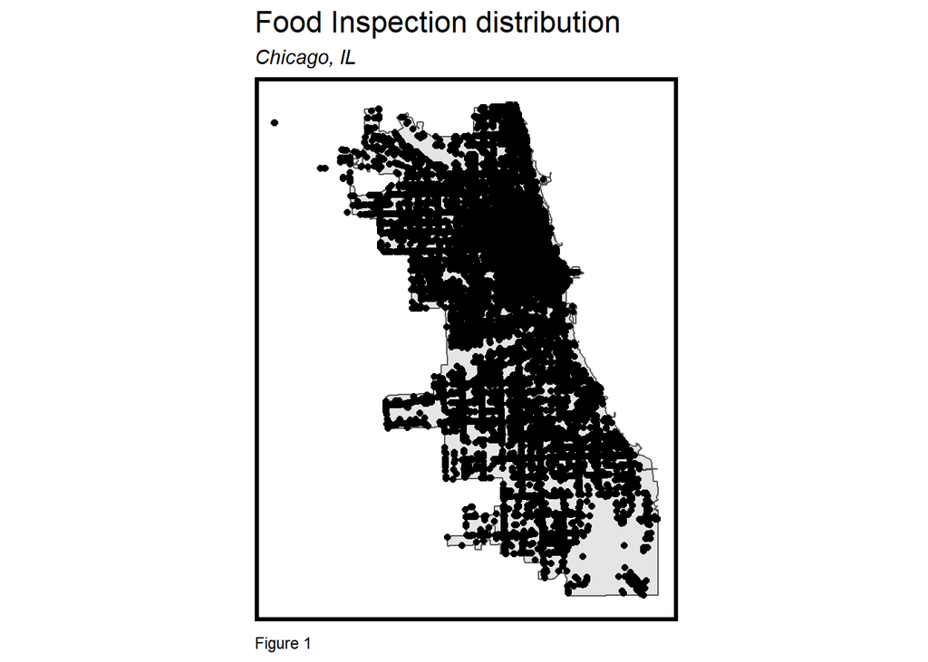

```r
foodinspection <-
  read.socrata("https://data.cityofchicago.org/resource/4ijn-s7e5.csv") %>%
  mutate(X = as.numeric(latitude),
         Y = as.numeric(longitude)) %>%
  filter(!is.na(X)) %>%
  filter(!is.na(Y)) %>%  st_as_sf(coords = c("Y", "X"), crs = 4326, agr = "constant")  %>%
  st_transform('ESRI:102271')

ggplot() +
   geom_sf(data= chicagoBoundary)+
   geom_sf(data= foodinspection) +
   labs(title = "Food Inspection distribution", subtitle = "Chicago, IL", caption="Figure 1") +
   mapTheme()
```

The raw data record tons of inspections from 2010 to 2020.

## 2.2 Tidy up P/F results

We consider “Pass” and “Pass with conditions” as PASS, consider Fail as FAIL. We exclude “No Entry”, “Not Ready”, and “Out of Business” because we have no idea whether they are PASS or FAIL. We mark PASS as 1 and Fail (No PASS) as 0.

```r
# restaurantinspection <- foodinspection%>%
#   dplyr::filter(facility_type == "Restaurant")

table1 <- foodinspection %>%
  dplyr::filter(results=="Fail"| results=="Pass"| results=="Pass w/ Conditions")%>%
  mutate(binary_results = as.numeric(ifelse(results == "Fail", 0, 1)))
```

# 3. Indicators

We would like to predict the 2020 inspection data based on indicators from both micro-scale and macro scale. Micro-scale: Past inspection data Macro-scale: Census tract data, 311 Request data

## 3.1 Past inspection data

### 3.1.1 Create indicators: “Pass rate” and “First time inspection”

We would like to create two features from the past inspection results:

To create such two indicators, we start off by marking the sites that have not been inspected before.

```r
table1_2 <- table1 %>%
  group_by(dba_name,binary_results) %>%
  summarize(counts1 = n()) %>%
  dplyr::filter(binary_results == 1) %>%
  st_drop_geometry()

table1_3 <- table1 %>%
  group_by(dba_name) %>%
  summarize(counts = n()) %>%
  st_drop_geometry()

table1 <- table1 %>%
  left_join(table1_2[,-2], by ="dba_name")  %>%
  left_join(table1_3, by ="dba_name")

table1[is.na(table1)] <- 0
```

We can calculate the ratio of pass and decide if it is the first time inspection.

```r
table1 <- table1 %>%
  mutate(ratio_pass = table1$counts1/ table1$counts) %>%
  mutate(first_time = as.factor(ifelse(counts == 1, 1, 0)))
```

### 3.1.2 Select the 2020 data.

We select the 2020 data for later prediction. There is more than one inspection for some of the sites in 2020, we contain all the inspection data because we find the results are extremely unbalanced if only choose the latest inspection results.

```r
# library(lubridate)
# introduction about the package: https://zhuanlan.zhihu.com/p/27612862

table1$month <- month(table1$inspection_date)
table1$year <- year(table1$inspection_date)
table2 <- table1 %>% filter(year == 2020)
```

## 3.2 Census data

We would like to take census tract data into consideration. We would like to check if demographic data such as race and income will influence the food safety.

### 3.2.1 Read in census data

Read in Chicago census data and select the raw demographic data.

```r
tract18 <-
  get_acs(geography = "tract", variables = c("B25026_001E","B02001_002E","B15001_050E",
                                             "B15001_009E","B19013_001E","B25058_001E",
                                             "B06012_002E"),
          year = 2018, state=17, county=031, geometry=T) %>%
  st_transform('ESRI:102271')

mask <-
  filter(chicagoBoundary) %>%
  st_centroid() %>%
  st_buffer(5280 * 5)

tract18 <-
  tract18[mask,]
```

Reshape long data to wide data

```r
tract18Wide <-
  tract18 %>%
  dplyr::select( -NAME, -moe) %>%
  spread(variable, estimate) %>%
  dplyr::select(-geometry) %>%
  rename(TotalPop = B25026_001,
         Whites = B02001_002,
         FemaleBachelors = B15001_050,
         MaleBachelors = B15001_009,
         MedHHInc = B19013_001,
         MedRent = B25058_001,
         TotalPoverty = B06012_002)
```

Calculate demographic features in each tracts, including percentage of white, percentage of bachelors,percentage of proverty

```r
tract18Wide <-
  tract18Wide %>%
  mutate(pctWhite = ifelse(TotalPop > 0, Whites / TotalPop, 0),
         pctBachelors = ifelse(TotalPop > 0, ((FemaleBachelors + MaleBachelors) / TotalPop), 0),
         pctPoverty = ifelse(TotalPop > 0, TotalPoverty / TotalPop, 0),
         year = "2018") %>%
  dplyr::select(-Whites,-FemaleBachelors,-MaleBachelors,-TotalPoverty)

st_drop_geometry(tract18Wide)[1:3,]
```

```
##         GEOID MedHHInc TotalPop MedRent  pctWhite pctBachelors pctPoverty year
## 1 17031010100    37985     4378     778 0.4837825  0.017359525  0.3606670 2018
## 2 17031010201    39549     6858     973 0.4946048  0.007290755  0.3773695 2018
## 3 17031010202    38370     2538     874 0.4984240  0.010244287  0.1840032 2018
```

### 3.2.2 Visualize the demographic data

Population

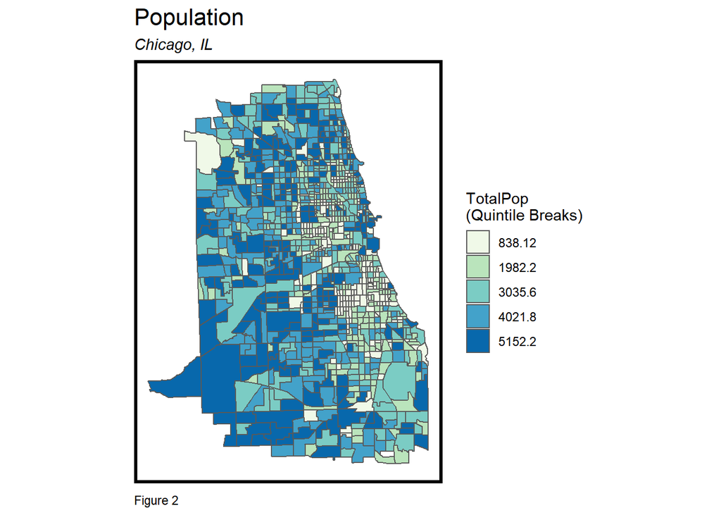

```r
ggplot(tract18Wide)+
    geom_sf(aes(fill = q5(TotalPop))) +
    scale_fill_manual(values = palette5,
                      labels = qBr(tract18Wide, "TotalPop"),
                      name = "TotalPop\n(Quintile Breaks)") +
    labs(title = "Population", subtitle = "Chicago, IL", caption="Figure 2") +
    mapTheme() +
    theme(plot.title = element_text(size=16))
```

Percentage of Whiite

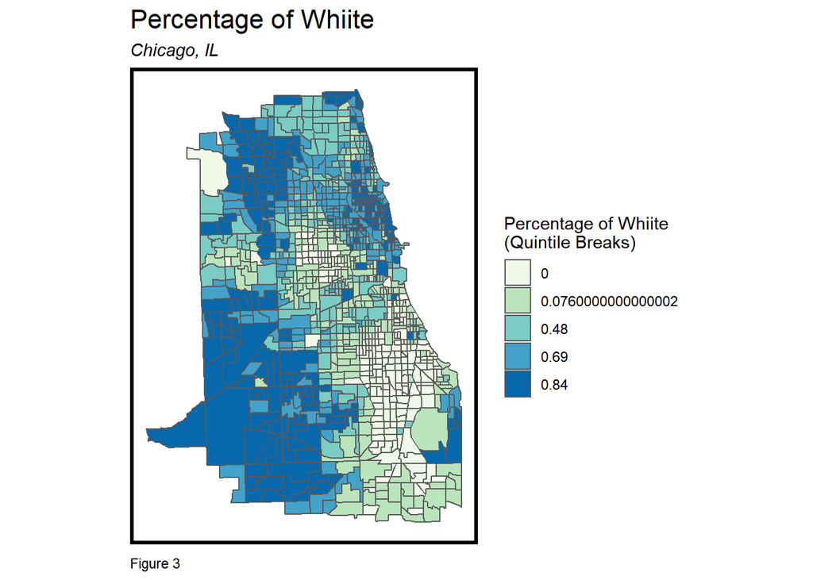

```r
ggplot(tract18Wide)+
    geom_sf(aes(fill = q5(pctWhite))) +
    scale_fill_manual(values = palette5,
                      labels = qBr(tract18Wide, "pctWhite"),
                      name = "Percentage of Whiite\n(Quintile Breaks)") +
    labs(title = "Percentage of Whiite", subtitle = "Chicago, IL", caption="Figure 3") +
     mapTheme() +
    theme(plot.title = element_text(size=16))
```

Percentage of Poverty

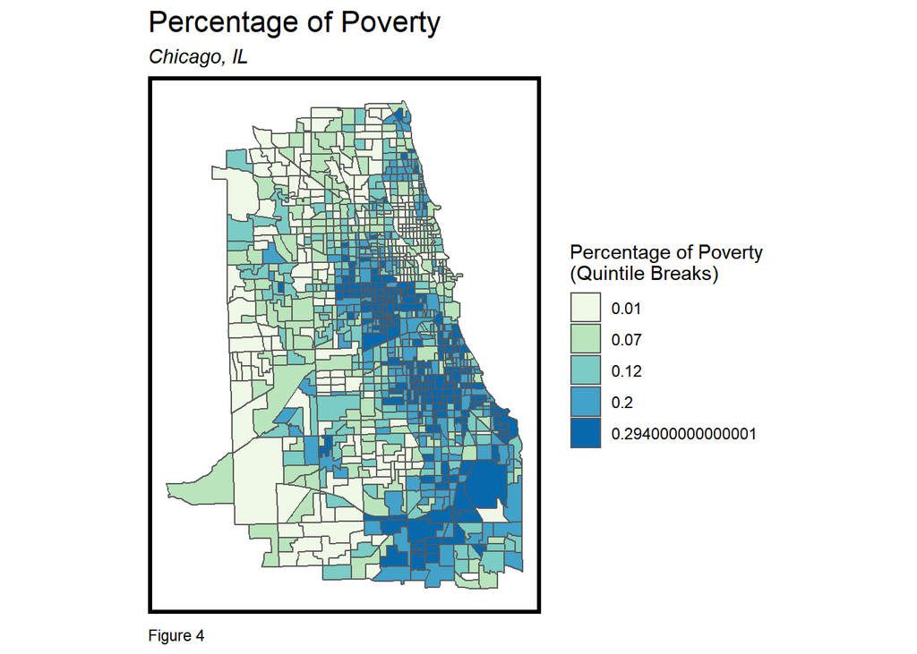

```r
ggplot(tract18Wide)+
    geom_sf(aes(fill = q5(pctPoverty))) +
    scale_fill_manual(values = palette5,
                      labels = qBr(tract18Wide, "pctPoverty"),
                      name = "Percentage of Poverty\n(Quintile Breaks)") +
    labs(title = "Percentage of Poverty", subtitle = "Chicago, IL", caption="Figure 4") +
    mapTheme() +
    theme(plot.title = element_text(size=16))
```

### 3.2.3 Feature engineering - spatial join

Spatial join the census data to the inspection data by st_within

```r
table2 <- st_join(table2, tract18Wide[,-8] , join = st_within) %>%
  st_drop_geometry() %>%
  left_join(table2)%>%
  st_sf()
```

## 3.3 Other data to show potential of P/F

We would like to take some other macro-scale data into consideration - to see if they can help to illustrate some of the latent risks causing FAIL. Here we import the public health request data including sanitation code complaints and rodent baiting data.

### 3.3.1 Import data

311 Request data - Sanitation Code Complaints

– The dataset records open sanitation code complaints made to 311 and all requests completed since January 1, 2011 – Residents may request service for violations such as overflowing dumpsters and garbage in the alley. We consider that a higher density of sanitation code complaints may indicate a worse sanitation, which may lead to a higher potential to fail the inspection.

```r
# https://data.cityofchicago.org/Service-Requests/311-Service-Requests-Sanitation-Code-Complaints-No/rccf-5427

sanitation <- st_read("https://data.cityofchicago.org/resource/rccf-5427.geojson") %>%
  st_transform('ESRI:102271')
```

Visualize the distribution of Sanitation Code Complaints

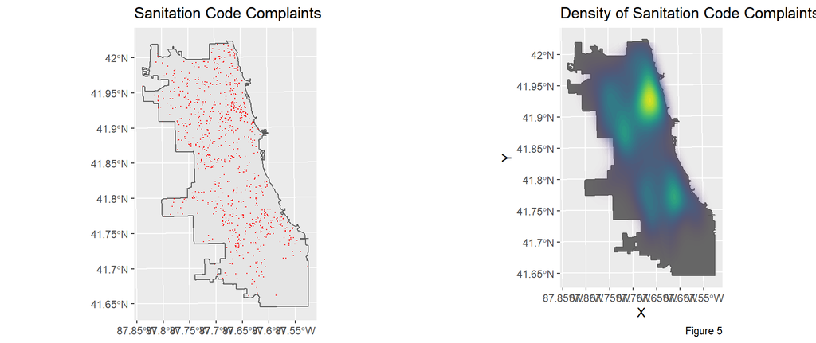

```r
grid.arrange(ncol=2,
ggplot() +
  geom_sf(data = chicagoBoundary) +
  geom_sf(data = sanitation, colour="red", size=0.1, show.legend = "point") +
  labs(title= "Sanitation Code Complaints"),

ggplot() +
  geom_sf(data = chicagoBoundary, fill = "grey40") +
  stat_density2d(data = data.frame(st_coordinates(st_centroid(sanitation))),
                 aes(X, Y, fill = ..level.., alpha = ..level..),
                 size = 0.01, bins = 40, geom = 'polygon') +
  scale_fill_viridis() +
  scale_alpha(range = c(0.00, 0.35), guide = FALSE) +
  labs(title = "Density of Sanitation Code Complaints", caption="Figure 5") +
  theme(legend.position = "none"))
```

311 Request data - Rodent Baiting

— The dataset records the open rodent baiting requests and rat complaints made to 311 and all requests completed since January 1, 2011. We consider that a higher density of Rodent baiting comlaints may indicate a worse sanitation, which may lead to a higher potential to fail the inspection.

```r
# https://data.cityofchicago.org/Service-Requests/311-Service-Requests-Rodent-Baiting-No-Duplicates/uqhs-j723
rodent <- st_read("https://data.cityofchicago.org/resource/uqhs-j723.geojson")%>%
  st_transform('ESRI:102271')
```

Visualize the distribution of Rodent Baiting Requests

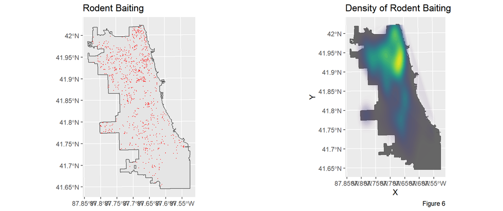

```r
grid.arrange(ncol=2,
ggplot() +
  geom_sf(data = chicagoBoundary) +
  geom_sf(data = rodent, colour="red", size=0.1, show.legend = "point") +
  labs(title= "Rodent Baiting"),

ggplot() +
  geom_sf(data = chicagoBoundary, fill = "grey40") +
  stat_density2d(data = data.frame(st_coordinates(st_centroid(rodent))),
                 aes(X, Y, fill = ..level.., alpha = ..level..),
                 size = 0.01, bins = 40, geom = 'polygon') +
  scale_fill_viridis() +
  scale_alpha(range = c(0.00, 0.35), guide = FALSE) +
  labs(title = "Density of Rodent Baiting", caption="Figure 6") +
  theme(legend.position = "none"))
```

### 3.3.2 Feature engineering -knn

We use knn to calculate how “close” it is from the request sites to the inspection points

```r
st_c <- st_coordinates

table2<-
 table2 %>%
    mutate(
      sanitation_nn1 = nn_function(st_c(st_centroid(table2)), st_c(st_centroid(sanitation)), 1),
      sanitation_nn2 = nn_function(st_c(st_centroid(table2)), st_c(st_centroid(sanitation)), 2),
      sanitation_nn3 = nn_function(st_c(st_centroid(table2)), st_c(st_centroid(sanitation)), 3))

table2<-
 table2 %>%
    mutate(
      rodent_nn1 = nn_function(st_c(st_centroid(table2)), st_c(st_centroid(rodent)), 1),
      rodent_nn2 = nn_function(st_c(st_centroid(table2)), st_c(st_centroid(rodent)), 2),
      rodent_nn3 = nn_function(st_c(st_centroid(table2)), st_c(st_centroid(rodent)), 3))
```

# 4 Data Exploration & Interpretation

We would like to list all the variables we have for the 2020 data below:

```r
names(table2)
```

```
##  [1] "inspection_id"   "dba_name"        "aka_name"        "license_"
##  [5] "facility_type"   "risk"            "address"         "city"
##  [9] "state"           "zip"             "inspection_date" "inspection_type"
## [13] "results"         "violations"      "latitude"        "longitude"
## [17] "location"        "binary_results"  "counts1"         "counts"
## [21] "ratio_pass"      "first_time"      "month"           "year"
## [25] "GEOID"           "MedHHInc"        "TotalPop"        "MedRent"
## [29] "pctWhite"        "pctBachelors"    "pctPoverty"      "geometry"
## [33] "sanitation_nn1"  "sanitation_nn2"  "sanitation_nn3"  "rodent_nn1"
## [37] "rodent_nn2"      "rodent_nn3"
```

Then we would like to select the relevant features in the chart. We will examine the numeric features and the categorical features below.

## 4.1 Numeric features

We would like to do correlation analysis for the numeric features.

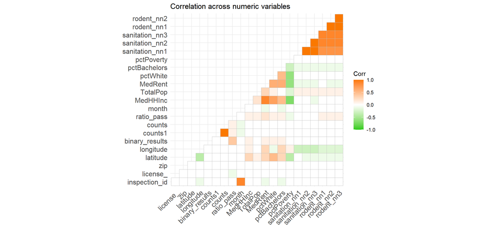

```r
numericVars <-
  select_if(table2, is.numeric) %>%
  na.omit()%>%
  st_drop_geometry()

ggcorrplot(
  round(cor(numericVars), 1),
  p.mat = cor_pmat(numericVars),
  colors = c("#25CB10", "white", "#FA7800"),
  type="lower",
  insig = "blank") +
    labs(title = "Correlation across numeric variables")
```

From the correlation results, the binary results (P/F) are closely relevant to the ratio of pass. They seems also relevant to some macro-scare data such as the Medient Rent. The results of rodent requests and the sanitation complaints are highly correlated, and we would not like to use more than one features among the six for the model.

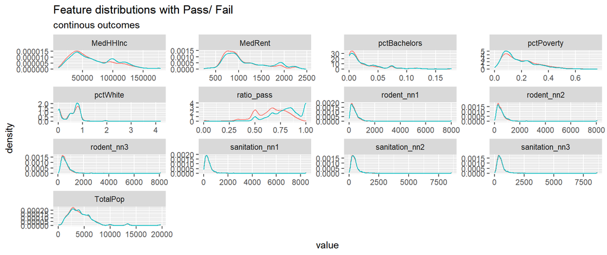

```r
table2 %>% st_drop_geometry() %>%
  dplyr::select(binary_results, ratio_pass, sanitation_nn1,  MedHHInc, TotalPop, MedRent, pctWhite, pctBachelors, pctPoverty, sanitation_nn2, sanitation_nn3, rodent_nn1, rodent_nn2,rodent_nn3) %>%
   gather(Variable, value, - binary_results) %>%
   ggplot() +
   geom_density(aes(value, color= as.character(binary_results)), fill = "transparent") +
   facet_wrap(~Variable, scales = "free") +
   scale_fill_manual(values = palette2) +
   labs(title = "Feature distributions with Pass/ Fail",
        subtitle = "continous outcomes") +
    theme(legend.position = "none")
```

As we can see, the pass rate (ratio_pass) largely influence the inspection results. Some features, such as the percentage of poverty, may have a larger influence on the results with in a certain threshold, and we may re-categorize these features later.

## 4.2 Category features

We create P/F bar charts for category features.

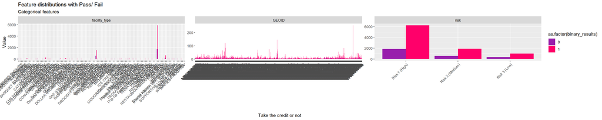

```r
table2 %>% st_drop_geometry() %>%
    dplyr::select(risk,binary_results,GEOID,facility_type) %>%
    gather(Variable, value, - binary_results) %>%
    count(Variable, value, binary_results) %>%
      ggplot(., aes(value, n, fill = as.factor(binary_results))) +
        geom_bar(position = "dodge", stat="identity") +
        facet_wrap(~Variable, scales="free") +
        scale_fill_manual(values = palette2) +
        labs(x="Take the credit or not", y="Value",
             title = "Feature distributions with Pass/ Fail",
             subtitle = "Categorical features") +
        theme(axis.text.x = element_text(angle = 45, hjust = 1))
```

## 4.3 Feature engineering

We re-categorize some of the features according to the analysis above.

```r
table2 <- table2  %>%
  mutate (pctProverty_Cat =
            case_when(pctPoverty >= 0.16 ~ "High",
                      pctPoverty < 0.16  ~ "Low" ))
```

# 5 Predict the P/F results with Logistic Regression Model

We would like to use a logistic regression model with the data in chart. The predicted results will fall into either PASS (1) or FAIL (NO PASS, 0)。

## 5.1 Split the data into Train set & Test set

```r
set.seed(3465)
trainIndex <- createDataPartition(table2$binary_results,y = paste(table2$GEOID),p = .70,
                                  list = FALSE, times = 1)

# trainIndex <- createDataPartition(table2$binary_results,y = paste(table2$GEOID),p = .65,
#                                  list = FALSE, times = 1)

datTrain <- table2[ trainIndex,] %>% st_drop_geometry()
datTest  <- table2[-trainIndex,] %>% st_drop_geometry()
```

## 5.2 Create Logistic Regression model

We create logistic regression model by macro-scale and micro-scale data.

```r
Model_01 <- glm(datTrain$binary_results ~ .,
                  data= datTrain %>%
                  dplyr::select(risk,ratio_pass,first_time, MedHHInc,MedRent,sanitation_nn3,pctWhite),
                  family="binomial" (link="logit"))

summary(Model_01)
```

```
##
## Call:
## glm(formula = datTrain$binary_results ~ ., family = binomial(link = "logit"),
##     data = datTrain %>% dplyr::select(risk, ratio_pass, first_time,
##         MedHHInc, MedRent, sanitation_nn3, pctWhite))
##
## Deviance Residuals:
##     Min       1Q   Median       3Q      Max
## -2.3525   0.1439   0.5007   0.6967   1.9625
##
## Coefficients:
##                         Estimate   Std. Error z value             Pr(>|z|)
## (Intercept)         -3.564519596  0.155885267 -22.866 < 0.0000000000000002 ***
## riskRisk 2 (Medium)  0.126266648  0.071233588   1.773             0.076300 .
## riskRisk 3 (Low)     0.355080350  0.092143838   3.854             0.000116 ***
## ratio_pass           6.186454425  0.194556573  31.798 < 0.0000000000000002 ***
## first_time1          1.784061039  0.457728270   3.898            0.0000971 ***
## MedHHInc            -0.000003296  0.000001790  -1.841             0.065628 .
## MedRent              0.000254224  0.000123759   2.054             0.039958 *
## sanitation_nn3       0.000049964  0.000046767   1.068             0.285358
## pctWhite             0.076875421  0.113581714   0.677             0.498514
## ---
## Signif. codes:  0 '***' 0.001 '**' 0.01 '*' 0.05 '.' 0.1 ' ' 1
##
## (Dispersion parameter for binomial family taken to be 1)
##
##     Null deviance: 9360.5  on 8669  degrees of freedom
## Residual deviance: 7968.0  on 8661  degrees of freedom
##   (58 observations deleted due to missingness)
## AIC: 7986
##
## Number of Fisher Scoring iterations: 6
```

From the summarized results, most of the factors in the model have shown kind of statistic significance.

```r
summ(Model_01)
```

| Observations | 8670 (58 missing obs. deleted) |
| --- | --- |
| Dependent variable | datTrain$binary_results |
| Type | Generalized linear model |
| Family | binomial |
| Link | logit |

| χ2(8) | 1392.43 |
| --- | --- |
| Pseudo-R2 (Cragg-Uhler) | 0.22 |
| Pseudo-R2 (McFadden) | 0.15 |
| AIC | 7986.04 |
| BIC | 8049.65 |

|  | Est. | S.E. | z val. | p |
| --- | --- | --- | --- | --- |
| (Intercept) | -3.56 | 0.16 | -22.87 | 0.00 |
| riskRisk 2 (Medium) | 0.13 | 0.07 | 1.77 | 0.08 |
| riskRisk 3 (Low) | 0.36 | 0.09 | 3.85 | 0.00 |
| ratio_pass | 6.19 | 0.19 | 31.80 | 0.00 |
| first_time1 | 1.78 | 0.46 | 3.90 | 0.00 |
| MedHHInc | -0.00 | 0.00 | -1.84 | 0.07 |
| MedRent | 0.00 | 0.00 | 2.05 | 0.04 |
| sanitation_nn3 | 0.00 | 0.00 | 1.07 | 0.29 |
| pctWhite | 0.08 | 0.11 | 0.68 | 0.50 |

Standard errors: MLE

```r
pR2(Model_01)
```

[output not shown]

## 5.3 Make predictions

Then we the train model to predict the inspection results in the test set.

```r
Pred_01 <- data.frame(Outcome = as.factor(datTest$binary_results),
                        Probs = predict(Model_01, datTest, type= "response"))
```

# 6.Model validation

We would like to examine the accuracy (sensitivity and specificity), ROC Curve and Cross validation.

## 6.1 Accuracy (Sensitivity and Specificity)

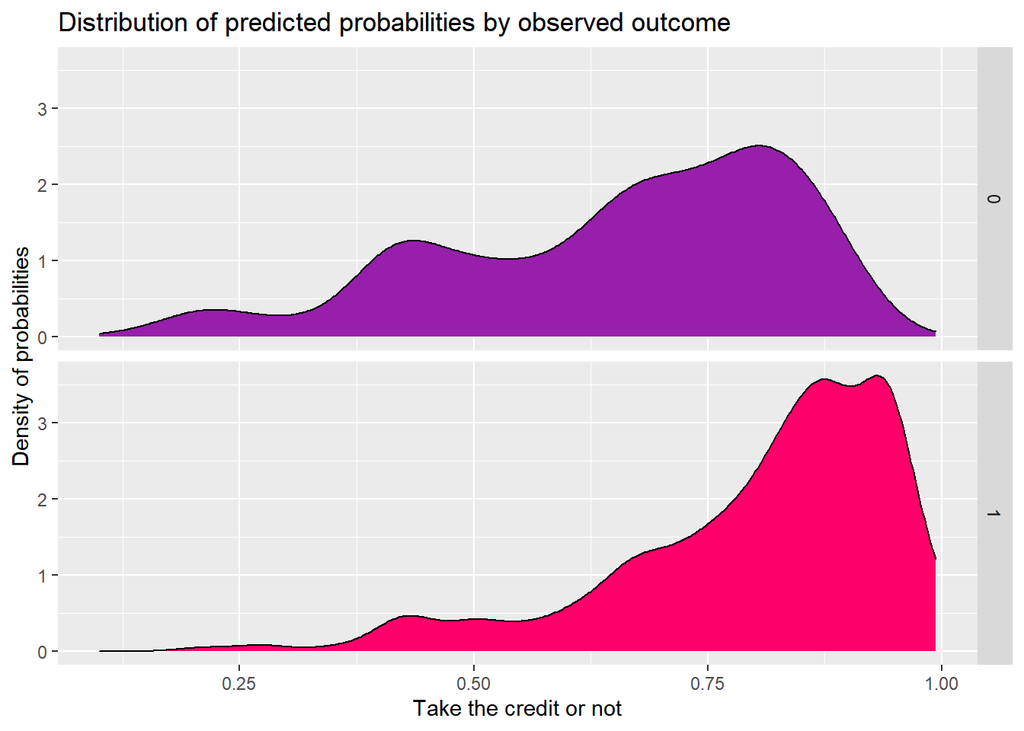

```r
ggplot(Pred_01, aes(x = Probs, fill = as.factor(Outcome))) +
  geom_density() +
  facet_grid(Outcome ~ .) +
  scale_fill_manual(values = palette2) +
  labs(x = "Take the credit or not", y = "Density of probabilities",
       title = "Distribution of predicted probabilities by observed outcome") +
  theme(strip.text.x = element_text(size = 18),
        legend.position = "none")
```

We modify the threshold from 0.5 to 0.77 and create a confusion matrix as below:

```r
Pred_01 <-
  Pred_01 %>%
  mutate(predOutcome  = as.factor(ifelse(Pred_01$Probs > 0.77 , 1, 0)))

caret::confusionMatrix(Pred_01$predOutcome, Pred_01$Outcome,
                       positive = "1")
```

```
## Confusion Matrix and Statistics
##
##           Reference
## Prediction    0    1
##          0  526  761
##          1  271 1647
##
##                Accuracy : 0.678
##                  95% CI : (0.6615, 0.6942)
##     No Information Rate : 0.7513
##     P-Value [Acc > NIR] : 1
##
##                   Kappa : 0.2853
##
##  Mcnemar's Test P-Value : <0.0000000000000002
##
##             Sensitivity : 0.6840
##             Specificity : 0.6600
##          Pos Pred Value : 0.8587
##          Neg Pred Value : 0.4087
##              Prevalence : 0.7513
##          Detection Rate : 0.5139
##    Detection Prevalence : 0.5984
##       Balanced Accuracy : 0.6720
##
##        'Positive' Class : 1
##
```

## 6.2 ROC Curve

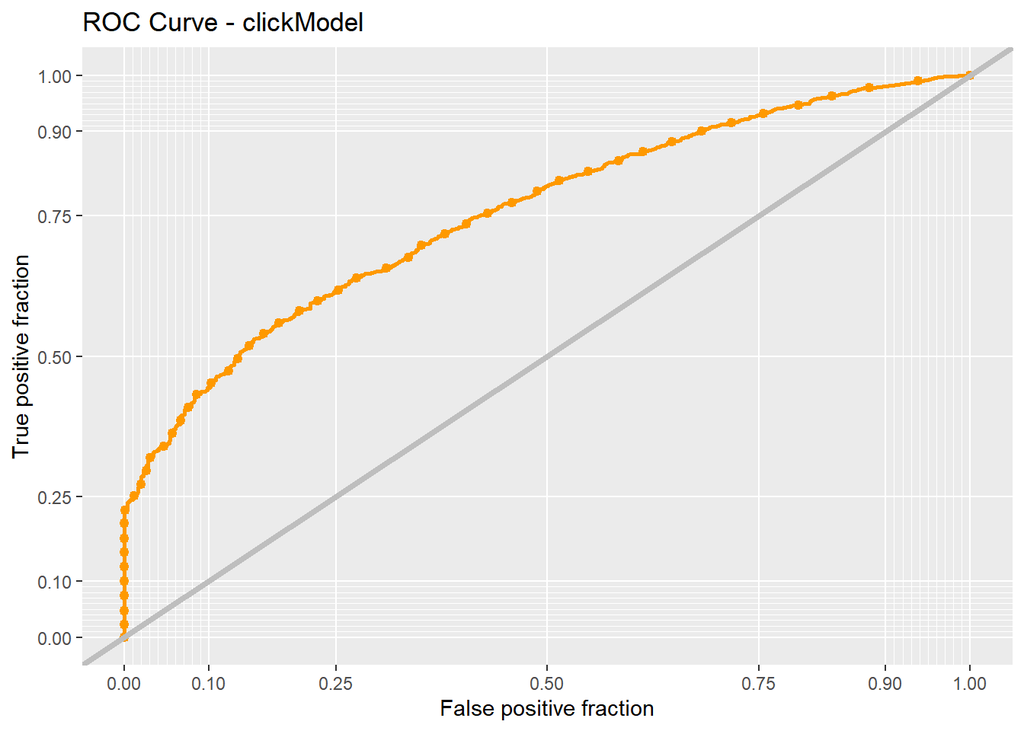

```r
ggplot(Pred_01, aes(d = as.numeric(Pred_01$Outcome), m = Probs)) +
  geom_roc(n.cuts = 50, labels = FALSE, colour = "#FE9900") +
  style_roc(theme = theme_grey) +
  geom_abline(slope = 1, intercept = 0, size = 1.5, color = 'grey') +
  labs(title = "ROC Curve - clickModel")
```

The ROC Curve visualizing trade-offs for two important confusion metrics.

According to the ROC Curve, a threshold that predicts “Pass the inspection” correctly 75% of the time, will predict “Pass the inspection” incorrectly about 37% of the time. The ‘Area Under the Curve’ metric or AUC is between 0.5 and 1, which means that it is reasonable goodness of fit.

## 6.3 Cross validation

We run a 100-fold cross validation here to avoid the biased causing by splitting the data.

```r
ctrl <- trainControl(method = "cv", number = 100, classProbs=TRUE, summaryFunction=twoClassSummary)

table3 <- table2 %>%  st_drop_geometry()
table3 <- table3 %>%
   dplyr::mutate(results_numeric = ifelse(binary_results == 0 ,"fail","pass")) %>% na.omit()

# sum(is.na(table3$binary_results))

dat_cvFit <- train(results_numeric ~ .,
                  data=table3 %>%
                    dplyr::select(risk, ratio_pass,first_time, sanitation_nn2, MedHHInc, MedRent, pctWhite, pctProverty_Cat,results_numeric),
                method="glm", family="binomial",
                metric="ROC", trControl = ctrl)

dat_cvFit
```

```
## Generalized Linear Model
##
## 11875 samples
##     8 predictor
##     2 classes: 'fail', 'pass'
##
## No pre-processing
## Resampling: Cross-Validated (100 fold)
## Summary of sample sizes: 11756, 11757, 11756, 11756, 11756, 11756, ...
## Resampling results:
##
##   ROC        Sens       Spec
##   0.7598454  0.2482937  0.9333516
```

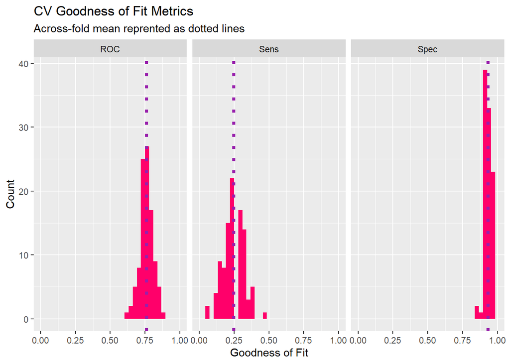

```r
dplyr::select(dat_cvFit$resample, -Resample) %>%
  gather(metric, value) %>%
  left_join(gather(dat_cvFit$results[2:4], metric, mean)) %>%
  ggplot(aes(value)) +
    geom_histogram(bins=35, fill = "#FF006A") +
    facet_wrap(~metric) +
    geom_vline(aes(xintercept = mean), colour = "#981FAC", linetype = 3, size = 1.5) +
    scale_x_continuous(limits = c(0, 1)) +
    labs(x="Goodness of Fit", y="Count", title="CV Goodness of Fit Metrics",
         subtitle = "Across-fold mean reprented as dotted lines")
```

The average of the AUC of the ROC is clustered arounf 0.75. The results of sensitivity and the specificity can be improved by switching the defaulted threshold as we did in Section 6.1.

# 7 Cost-benefit calculation and the thesholds

We Would like to provide a use case of cost-Benefit calculation and show how we can improve the model by choosing the best threshold with the cost/benefit calculation results.

(The cost/benefit data are not the real data - just a prediction to help illustrate how to improve the model)

## 7.1 create cost/benefit table

Assumption:

Predict to fail the next inspections - spend $500 for the next inspections Predict to pass the next inspections - spend $100 for the next inspections A restaurant qualified the inspection criteria can serve the public by providing $800 benefits A restaurant unqualified the inspection criteria harm the public by $2000 cost (if not stopped by the government)

True_Positive: predict to pass the inspections, do pass the inspections cost/benefit: -$100 +$800 =$700

False_Negative: Predict to fail the inspections, while in fact pass the inspections cost/benefit: -$500 +$800 = $300

False_Positive:Predict to pass the inspections, while in fact fail the inspections 30% likelyhood to successfully protect the public from unsafe food (or other problems) cost/benefit: -$100 + 0.3*$800 - 0.7*2000 = - $1260

```r
cost_benefit_table <-
   Pred_01 %>%
      count(predOutcome, Outcome) %>%
      summarize(True_Negative = sum((n[predOutcome==0 & Outcome==0]),na.rm = T),
                True_Positive = sum((n[predOutcome==1 & Outcome==1]),na.rm = T),
                False_Negative = sum((n[predOutcome==0 & Outcome==1]),na.rm = T),
                False_Positive = sum((n[predOutcome==1 & Outcome==0]),na.rm = T)) %>%
       gather(Variable, Count) %>%
       mutate(Revenue =
               case_when(Variable == "True_Negative"  ~ (-500)*Count,
                         Variable == "True_Positive"  ~ (700) * Count,
                         Variable == "False_Negative" ~ (300)* Count,
                         Variable == "False_Positive" ~ (-1260) * Count)) %>%
    bind_cols(data.frame(Description = c(
              "We correctly predict a fail",
              "We correctly predict a pass",
              "We predict a fail but it should be a pass",
              "We predict a pass but it should be a fail")))

kable(cost_benefit_table,
       caption = "Cost/Benefit Table") %>% kable_styling()
```

Cost/Benefit Table

| Variable | Count | Revenue | Description |
| --- | --- | --- | --- |
| True_Negative | 526 | -263000 | We correctly predict a fail |
| True_Positive | 1647 | 1152900 | We correctly predict a pass |
| False_Negative | 761 | 228300 | We predict a fail but it should be a pass |
| False_Positive | 271 | -341460 | We predict a pass but it should be a fail |

## 7.2 Optimize thresholds

### 7.2.1 Iterate thresholds

```r
iterateThresholds <- function(data, observedClass, predictedProbs, group) {
#This function takes as its inputs, a data frame with an observed binomial class (1 or 0); a vector of predicted probabilities; and optionally a group indicator like race. It returns accuracy plus counts and rates of confusion matrix outcomes. It's a bit verbose because of the if (missing(group)). I don't know another way to make an optional parameter.
  observedClass <- enquo(observedClass)
  predictedProbs <- enquo(predictedProbs)
  group <- enquo(group)
  x = .01
  all_prediction <- data.frame()

  if (missing(group)) {

    while (x <= 1) {
    this_prediction <- data.frame()

    this_prediction <-
      data %>%
      mutate(predclass = ifelse(!!predictedProbs > x, 1,0)) %>%
      count(predclass, !!observedClass) %>%
      summarize(Count_TN = sum((n[predclass==0 & !!observedClass==0]),na.rm = T),
                Count_TP = sum((n[predclass==1 & !!observedClass==1]),na.rm = T),
                Count_FN = sum((n[predclass==0 & !!observedClass==1]),na.rm = T),
                Count_FP = sum((n[predclass==1 & !!observedClass==0]),na.rm = T),
                Rate_TP = Count_TP / (Count_TP + Count_FN),
                Rate_FP = Count_FP / (Count_FP + Count_TN),
                Rate_FN = Count_FN / (Count_FN + Count_TP),
                Rate_TN = Count_TN / (Count_TN + Count_FP),
                Accuracy = (Count_TP + Count_TN) /
                           (Count_TP + Count_TN + Count_FN + Count_FP)) %>%
      mutate(Threshold = round(x,2))

    all_prediction <- rbind(all_prediction,this_prediction)
    x <- x + .01
  }
  return(all_prediction)
  }
  else if (!missing(group)) {
   while (x <= 1) {
    this_prediction <- data.frame()

    this_prediction <-
      data %>%
      mutate(predclass = ifelse(!!predictedProbs > x, 1,0)) %>%
      group_by(!!group) %>%
      count(predclass, !!observedClass) %>%
      summarize(Count_TN = sum((n[predclass==0 & !!observedClass==0]),na.rm = T),
                Count_TP = sum((n[predclass==1 & !!observedClass==1]),na.rm = T),
                Count_FN = sum((n[predclass==0 & !!observedClass==1]),na.rm = T),
                Count_FP = sum((n[predclass==1 & !!observedClass==0]),na.rm = T),
                Rate_TP = Count_TP / (Count_TP + Count_FN),
                Rate_FP = Count_FP / (Count_FP + Count_TN),
                Rate_FN = Count_FN / (Count_FN + Count_TP),
                Rate_TN = Count_TN / (Count_TN + Count_FP),
                Accuracy = (Count_TP + Count_TN) /
                           (Count_TP + Count_TN + Count_FN + Count_FP)) %>%
      mutate(Threshold = round(x,2))

    all_prediction <- rbind(all_prediction,this_prediction)
    x <- x + .01
  }
  return(all_prediction)
  }
}
```

### 7.2.2 Plot the confusion metric outcomes for each threshold

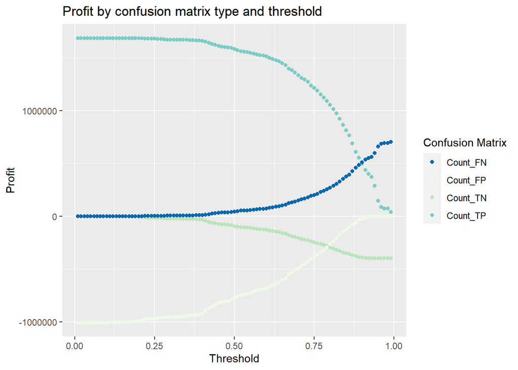

```r
whichThreshold <- iterateThresholds(Pred_01,observedClass = Outcome, predictedProbs = Probs)

whichThreshold <-
  whichThreshold %>%
    dplyr::select(starts_with("Count"), Threshold) %>%
    gather(Variable, Count, -Threshold) %>%
    mutate(Revenue =
                 case_when(Variable == "Count_TN"  ~ (-500)* Count,
                           Variable == "Count_TP"  ~ (700)* Count,
                           Variable == "Count_FN" ~ (300)* Count,
                           Variable == "Count_FP" ~ (-1260) * Count))

whichThreshold %>%
  ggplot(.,aes(Threshold, Revenue, colour = Variable)) +
  geom_point() +
  scale_colour_manual(values = palette5[c(5, 1:3)]) +
  labs(title = "Profit by confusion matrix type and threshold",
       y = "Profit") +
  guides(colour=guide_legend(title = "Confusion Matrix"))
```

From the chart, we can see how TN, TP, FP, and FN going up or down with the change of the threshold. Later we will sum up all these four categories as the total revenue.

### 7.2.3 Threshold as a function of total revenue

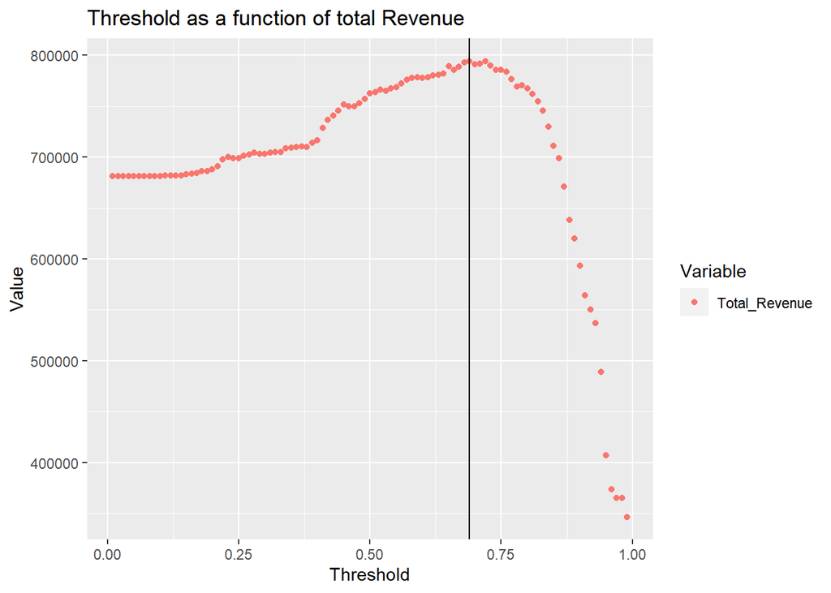

```r
whichThreshold_revenue <-
  whichThreshold %>%
   group_by(Threshold) %>%
    summarize(Total_Revenue = sum((Revenue),na.rm = T))

whichThreshold_revenue %>%
  dplyr::select(Threshold, Total_Revenue) %>%
  gather(Variable, Value, -Threshold) %>%
  ggplot(aes(Threshold, Value, colour = Variable)) +
    geom_point() +
    geom_vline(xintercept = pull(arrange(whichThreshold_revenue, -Total_Revenue)[1,1])) +
    labs(title = "Threshold as a function of total Revenue" )
```